# 电商销售数据分析项目

## 项目背景

使用 UCI 的 Online Retail 数据集，分析某英国电商公司的交易记录，回答以下业务问题：

1. 月度销售额如何变化？什么时候是旺季？
2. 哪些国家贡献了最多的订单？
3. 哪些商品是最畅销的？

## 数据说明

```python
# 1. 导入 pandas 库，用于数据处理和分析
import pandas as pd

# 2. 导入 matplotlib 的 pyplot 模块，用于画图
import matplotlib.pyplot as plt

# 3. 设置 matplotlib 的中文显示（防止图表中的中文变成方框乱码）
plt.rcParams['font.sans-serif'] = ['SimHei']      # 指定默认字体为黑体
plt.rcParams['axes.unicode_minus'] = False        # 解决负号显示为方块的问题

# 4. 加载 Excel 数据文件
df = pd.read_excel('Online_Retail.xlsx')

# 5. 打印原始数据的行数（看看有多少条记录）
print("原始数据行数:", len(df))

# 6. 显示数据的前5行，快速预览数据结构（列名、内容样例）
df.head()
```

```
原始数据行数: 541909
```

|  | InvoiceNo | StockCode | Description | Quantity | InvoiceDate | UnitPrice | CustomerID | Country |
| --- | --- | --- | --- | --- | --- | --- | --- | --- |
| 0 | 536365 | 85123A | WHITE HANGING HEART T-LIGHT HOLDER | 6 | 2012-01-10 08:26:00 | 2.55 | 17850.0 | United Kingdom |
| 1 | 536365 | 71053 | WHITE METAL LANTERN | 6 | 2012-01-10 08:26:00 | 3.39 | 17850.0 | United Kingdom |
| 2 | 536365 | 84406B | CREAM CUPID HEARTS COAT HANGER | 8 | 2012-01-10 08:26:00 | 2.75 | 17850.0 | United Kingdom |
| 3 | 536365 | 84029G | KNITTED UNION FLAG HOT WATER BOTTLE | 6 | 2012-01-10 08:26:00 | 3.39 | 17850.0 | United Kingdom |
| 4 | 536365 | 84029E | RED WOOLLY HOTTIE WHITE HEART. | 6 | 2012-01-10 08:26:00 | 3.39 | 17850.0 | United Kingdom |

```python
      #数据清洗
# 1. 删除 CustomerID（客户ID）为空的行
#    因为这些行没有客户信息，后续无法做客户维度的分析
df = df.dropna(subset=['CustomerID'])

# 2. 删除 Quantity（数量）或 UnitPrice（单价）小于或等于0的行
#    数量或单价为0或负数通常是退货、错误数据或异常订单，会影响分析结果
df = df[(df['Quantity'] > 0) & (df['UnitPrice'] > 0)]

# 3. 添加新列 TotalPrice（总价）
#    总价 = 数量 × 单价，这是后续销售额统计的基础
df['TotalPrice'] = df['Quantity'] * df['UnitPrice']

# 4. 将 InvoiceDate（发票日期）列转换为 pandas 的 datetime 类型
#    转换后才能方便地提取年份、月份、星期等信息
df['InvoiceDate'] = pd.to_datetime(df['InvoiceDate'])

# 5. 提取月份，创建新列 Month（格式如 2010-12）
#    dt.to_period('M') 表示按“月”为单位，方便后续按月份分组
df['Month'] = df['InvoiceDate'].dt.to_period('M')

# 6. 打印清洗后的数据行数，看看删掉了多少异常数据
print("清洗后行数:", len(df))

# 7. 打印所有列名，确认清洗后添加了 TotalPrice 和 Month
print("列名:", df.columns.tolist())
```

```
清洗后行数: 397884
列名: ['InvoiceNo', 'StockCode', 'Description', 'Quantity', 'InvoiceDate', 'UnitPrice', 'CustomerID', 'Country', 'TotalPrice', 'Month']
```

[figure not shown]

```python
#  月度销售额趋势图

# 1. 按 Month（月份）分组，计算每个月的 TotalPrice（总销售额）总和
monthly_sales = df.groupby('Month')['TotalPrice'].sum()

# 2. 将月份索引转换为字符串类型
#    这样可以避免后续画图时因 Period 类型导致的显示问题
monthly_sales.index = monthly_sales.index.astype(str)

# 3. 画出折线图
#    kind='line'：折线图
#    figsize=(12,6)：设置图的大小（宽12英寸，高6英寸）
#    rot=45：将横坐标标签旋转45度，避免文字重叠
monthly_sales.plot(kind='line', figsize=(12,6), rot=45)

# 4. 设置图表的标题
plt.title('月度销售额趋势')

# 5. 设置横坐标的标签名称
plt.xlabel('月份')

# 6. 设置纵坐标的标签名称
plt.ylabel('总销售额')

# 7. 显示图表（在 Jupyter 中必须写这一行才能渲染出来）
plt.show()
```

> **结论**：11月销售额最高，是销售旺季；2月、8月为淡季。建议在10月下旬开始增加备货。

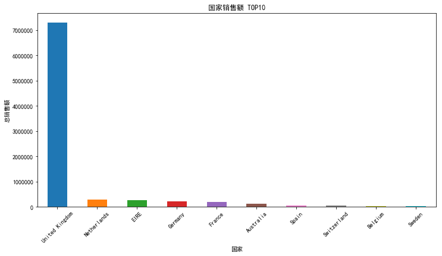

```python
#  国家销售额 TOP10 柱状图

# 1. 按 Country（国家）分组，计算每个国家的总销售额
#    然后按销售额从高到低排序，再取前10名
country_sales = (
    df.groupby('Country')['TotalPrice']
    .sum()                      # 计算总销售额
    .sort_values(ascending=False)  # 从高到低排序
    .head(10)                   # 取前10个
)

# 2. 画出柱状图（条形图）
#    kind='bar'：柱状图
#    figsize=(12,6)：图的大小
#    rot=45：横坐标标签旋转45度（国家名称较长时避免重叠）
country_sales.plot(kind='bar', figsize=(12,6), rot=45)

# 3. 图表标题
plt.title('国家销售额 TOP10')

# 4. 横坐标标签
plt.xlabel('国家')

# 5. 纵坐标标签
plt.ylabel('总销售额')

# 6. 显示图表
plt.show()
```

> **结论**：英国贡献了超过80%的销售额，是绝对核心市场；荷兰、德国、法国为第二梯队。

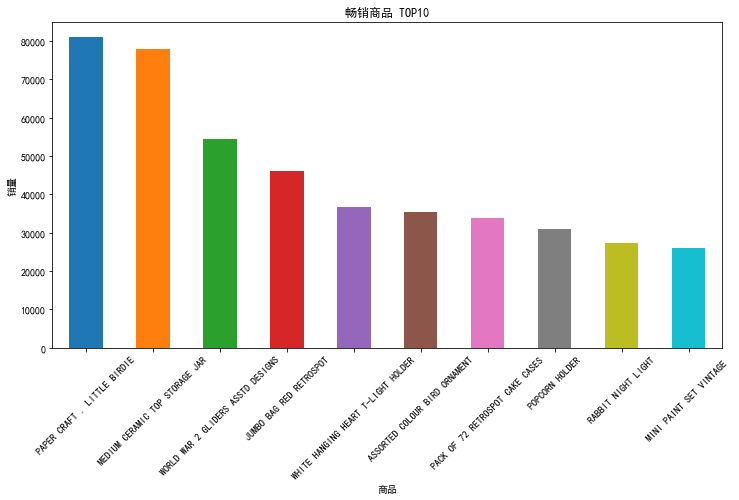

```python
#  畅销商品 TOP10（按销量）柱状图

# 1. 按 Description（商品描述）分组，计算每种商品的总销量（Quantity 总和）
#    然后按销量从高到低排序，取前10名
top_products = (
    df.groupby('Description')['Quantity']
    .sum()                       # 计算总销量
    .sort_values(ascending=False) # 从高到低排序
    .head(10)                    # 取前10个
)

# 2. 画出柱状图
top_products.plot(kind='bar', figsize=(12,6), rot=45)

# 3. 图表标题
plt.title('畅销商品 TOP10')

# 4. 横坐标标签
plt.xlabel('商品')

# 5. 纵坐标标签
plt.ylabel('销量')

# 6. 显示图表
plt.show()
```

## 项目总结

通过本次分析，得出以下可落地建议：

1. **备货策略**：重点围绕11月旺季，提前1个月加大采购和营销投入。
2. **市场策略**：优先保障英国市场的供应和体验，同时尝试在荷兰、德国进行轻度本地化运营。
3. **商品策略**：对Top5畅销品建立安全库存预警，设计畅销品+滞销品的捆绑套餐。

**技术栈**：Python (Pandas, Matplotlib)  
**代码仓库**：[https://github.com/Xiongxin720/xiong-ecommerce-data-analysis]